# Wenatchee 2015 Max

This set of R scripts processes logger data for predictive stream temperature modeling Created: 21 Feb 2017 Updated: 25 Apr 2017

Stage setting:

This part reads the LST data and gap-fills using a cubic spline function

```r
  LST.in <- read.dbf(paste0(gisPath, "/", midBasin, "/", basin, "_", yrPath, "_LST.dbf"))
  PointID <- LST.in[,1]
  LST.in <- LST.in[,2:47]
  LST.in[LST.in<0.1] = NA

  LST.names<-colnames(LST.in)

  myFunc <- function(x)
    {
      if (is.na(x[1]))
      {
        x[1] <- 13022
      }
      x
    }

  LST.filled <- apply(LST.in, 1, function(x) myFunc(x))
  LST.filled <- as.data.frame(t(LST.filled))


  myFunc2 <- function(x)
    {
      if (is.na(x[46]))
      {
        x[46] <- x[43]
      }
      x
    }


  LST.filled <- apply(LST.filled, 1, function(x) myFunc2(x))
  LST.filled <- as.data.frame(t(LST.filled))

  myFunc3 <- function(x)
    {
      if (is.na(x[46]))
      {
        x[46] <- 12943
      }
      x
    }

  LST.filled <- apply(LST.filled, 1, function(x) myFunc3(x))
  LST.filled <- as.data.frame(t(LST.filled))

  tLST.in <- t(LST.filled)

  tLST.out <- na.spline(tLST.in)
  CLST <- tLST.out*0.02-273.15
  tCLST <- t(CLST)
  CLST.out <- as.data.frame(tCLST)


  CLST.out$PointID <- PointID
  colnames(CLST.out)[1:46] <- LST.names
```

Plot to look

```r
  plot(1:46, CLST.out[1,1:46])
  plot(1:46, CLST.out[1000,1:46])

  write.dbf(CLST.out, file = paste0(mainPath, longBasin, "/", "LST", yrPath, "_", basin, "_interp.dbf"))
```

This part calculates the zonal mean of the daily LST for each RCA

```r
out_Preds <- read.dbf(paste0(mainPath, longBasin, "/", "LST", yrPath, "_", basin, "_interp.dbf"))


  weights <- read.csv(paste0(mainPath, "/", longBasin, "/", basin, "_rca_area_wgts.csv"), stringsAsFactors=FALSE)
  weights[weights$area_wgt<0.01, "area_wgt"] = 0.01

  rcas <- unique(unlist(weights$RCAID))
  rca_zonal <- matrix(ncol=46, nrow=length(rcas))


  l <- 1

  for(i in rcas)
    {
      pixels <- weights[weights$RCAID == i, "GRIDCODE"]
      wgts <- weights[weights$RCAID == i, "area_wgt"]

      for (j in 1:46)
      {
        daily <- out_Preds[out_Preds$PointID %in% pixels, j]
        zonal_mn <- weighted.mean(daily, wgts, na.rm = TRUE)
        rca_zonal[l,j] <- zonal_mn
      }
      l <- l+1
    }


  colnames(rca_zonal)[1:46] <- colnames(out_Preds)[1:46]
  rca_zonal <- as.data.frame(rca_zonal)
  rca_zonal$RCAID <- rcas
```

Plot to look

```r
  plot(1:46, rca_zonal[1,1:46])
  plot(1:46, rca_zonal[1000,1:46])
  write.dbf(rca_zonal, file = paste0("../", "LST", yrPath, "_", basin, "_RCA.dbf"))
```

Model building

```r
  Log.in <- read.csv(paste0("../../", basin, "_logger_8D_", yearPath, ".csv"), stringsAsFactors = FALSE)

  ID.in <- read.csv(paste0("../../", basin, "_sites_elev.csv"), stringsAsFactors=FALSE)
  colnames(ID.in)[1] <- "SiteID"

  LST.in <- read.dbf(paste0(mainPath, longBasin, "/", "LST", yrPath, "_", basin, "_RCA.dbf"))
  colnames(LST.in)<-gsub("X", "", colnames(LST.in))
  newnamesnum <- as.numeric(colnames(LST.in)[1:46]);

  LST.Log.out <- data.frame (mup = NULL)
  SiteID <- unique(Log.in$SiteName)

  for (i in SiteID)
    {
      Log.site <- Log.in[Log.in$SiteName  == i,]
      Log.site <- as.data.frame(Log.site)

      RCAID <- ID.in$RCAID[ID.in$SiteID == i]
      Elev <- ID.in$Elev[ID.in$SiteID == i]

      LST.site <- matrix(ncol=3, nrow=46)
      LST.site[,1] <- as.numeric(unlist(colnames(LST.in)[1:46]))
      LST.site[,2] <- unlist(LST.in[RCAID,1:46])
      LST.site <- data.frame(LST.site)
      colnames(LST.site) <- c("JulDay", "LST", "Elev")
      LST.site[3] <- Elev
      LST.Log.site <- merge(LST.site, Log.site, by.x = "JulDay",by.y = "JulDay", all.x=TRUE, all.y = FALSE)

      LST.Log.out <- rbind(LST.Log.out, LST.Log.site)
    }


  ind <- apply(LST.Log.out, 1, function(x) !any(is.na(x)))
  NoNA.xyz <- LST.Log.out[ind,]

  NoNA.xyz <- NoNA.xyz[,c(9, 2, 1, 3, 5)]
  colnames(NoNA.xyz) <- c("y", "x", "z", "e", "SiteName")

  write.csv(x=NoNA.xyz, file= paste0(basin, "_", yearPath, "_8Day_", var, "_model_data.csv"), row.names = FALSE)

  NoNA.xyz <- orderBy(~z, NoNA.xyz)
  maxrow <- which.max(NoNA.xyz$y)
  data.sp <- NoNA.xyz[1:(maxrow-1),]
  rownames(data.sp) <- 1:dim(data.sp)[1]
  data.fall <- NoNA.xyz[maxrow:nrow(NoNA.xyz),]
  rownames(data.fall) <- 1:dim(data.fall)[1]
```

plot the data

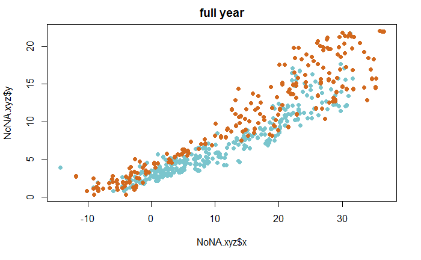

```r
  {plot(NoNA.xyz$x, NoNA.xyz$y, main = "full year")
  points(data.sp$x, data.sp$y, pch=16, col="cadetblue3")
  points(data.fall$x, data.fall$y, pch=16, col="chocolate")}
```

```r
NA
```

#### Full year models

```r
  y <- NoNA.xyz$y
  x <- NoNA.xyz$x
  z <- NoNA.xyz$z
  e <- NoNA.xyz$e

  mod <- lm(y ~ x + I(x^2) + e)
  sum_mod <- summary(mod)
  sum_mod
```

```
Call:
lm(formula = y ~ x + I(x^2) + e)

Residuals:
    Min      1Q  Median      3Q     Max
-5.5871 -1.2373 -0.2740  0.9623  7.6619

Coefficients:
              Estimate Std. Error t value Pr(>|t|)
(Intercept)  3.8484412  0.2507702  15.346  < 2e-16 ***
x            0.2979115  0.0176794  16.851  < 2e-16 ***
I(x^2)       0.0048299  0.0006404   7.542  1.7e-13 ***
e           -0.0011906  0.0003781  -3.149  0.00172 **
---
Signif. codes:  0 ‘***’ 0.001 ‘**’ 0.01 ‘*’ 0.05 ‘.’ 0.1 ‘ ’ 1

Residual standard error: 2.081 on 605 degrees of freedom
Multiple R-squared:  0.8536,    Adjusted R-squared:  0.8529
F-statistic:  1176 on 3 and 605 DF,  p-value: < 2.2e-16
```

Model prediction

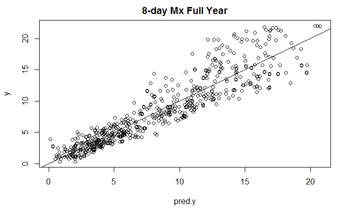

```r
  pred.y <- predict(mod)
  {plot(pred.y, y, main = paste0("8-day ", var, " Full Year"))
  abline(0,1)}
```

Model diagnostics

```r
  post_mod <- summary(lm(y ~ pred.y))
  gvmodel <- gvlma(mod)
  summary(gvmodel)
```

```r
  outlierTest(mod)
```

```r
  qqPlot(mod, main="QQ Plot Full Year")
```

Assumptions:

```r
plot(mod)
```

```r
  spreadLevelPlot(mod)
```

```r
  plot(pred.y, mod$residuals, main="Model diagnostics Full Year", xlab="Predicted", ylab="Residuals")
```

```r
  pressstat_sum <- PRESS(mod, verbose = "FALSE")
  RMSEP <- sqrt(mean((pressstat_sum$residuals)^2))

  library(pls)
  mod2 <- plsr(y ~ x + I(x^2) + e, validation = "LOO")
  p2 <- R2(mod2)
  detach("package:pls", unload=TRUE)

  coeffs <- as.matrix(coefficients(sum_mod))

  pred.out <- matrix(nrow=length(pred.y), ncol=5)
  pred.out[,1] <- y
  pred.out[,2] <- pred.y
  pred.out[,3] <- z
  pred.out[,4] <- "full year"
  pred.out[,5] <- yearPath
  colnames(pred.out) <- c("Y", "PredY", "JulDay", "Season", "Year")
  write.table (x=pred.out,append=T,row.names=F,file=paste0("jk_pred_v_y_", var, "_", basin, "_", yearPath, "_full_year.csv"),sep = ",", col.names=F)
```

```r
  fit <- lm(y~ pred.y)

  summary(fit)
```

Output tables formatting for coeffs and metrics

```r
  coeffs_out <- data.frame(Int=numeric(2), bLST=numeric(2), bLST2=numeric(2), bJul=numeric(2), bElev=numeric(2))
  metrics_out <- data.frame(r2=numeric(2), RMSE=numeric(2), p2=numeric(2), RMSEP=numeric(2), N_Sites=numeric(2), N=numeric(2))
  rownames(metrics_out) <- c("Spring", "Fall")
  rownames(coeffs_out) <- c("Spring", "Fall")
```

No Julday output

```r
  coeffs_out[1,1] <- coeffs[1,1]
  coeffs_out[1,2] <- coeffs[2,1]
  coeffs_out[1,3] <- coeffs[3,1]
  coeffs_out[1,4] <- 0
  coeffs_out[1,5] <- coeffs[4,1]

  metrics_out[1,1] <- sum_mod$adj.r.squared
  metrics_out[1,2] <- sum_mod$sigma
  metrics_out[1,3] <- p2$val[5]
  metrics_out[1,4] <- RMSEP
  metrics_out[1,5] <- length(unique(NoNA.xyz$SiteName))
  metrics_out[1,6] <- length(y)

  coeffs_out[2,1] <- coeffs[1,1]
  coeffs_out[2,2] <- coeffs[2,1]
  coeffs_out[2,3] <- coeffs[3,1]
  coeffs_out[2,4] <- 0
  coeffs_out[2,5] <- coeffs[4,1]

  metrics_out[2,1] <- sum_mod$adj.r.squared
  metrics_out[2,2] <- sum_mod$sigma
  metrics_out[2,3] <- p2$val[5]
  metrics_out[2,4] <- RMSEP
  metrics_out[2,5] <- length(unique(NoNA.xyz$SiteName))
  metrics_out[2,6] <- length(y)
```

Write stuff out

```r
  write.table(x=coeffs_out, append=F,row.names=T, file = paste0("All_data_", basin, "_", yearPath, "_mod_coeffs_", var, ".csv"), sep = ",", col.names=T)

  write.table(x=metrics_out, append=F,row.names=T, file = paste0("All_data_", basin, "_", yearPath, "_mod_metrics_", var, ".csv"), sep = ",", col.names=T)
```

#### Spring/Fall models

Spring data model

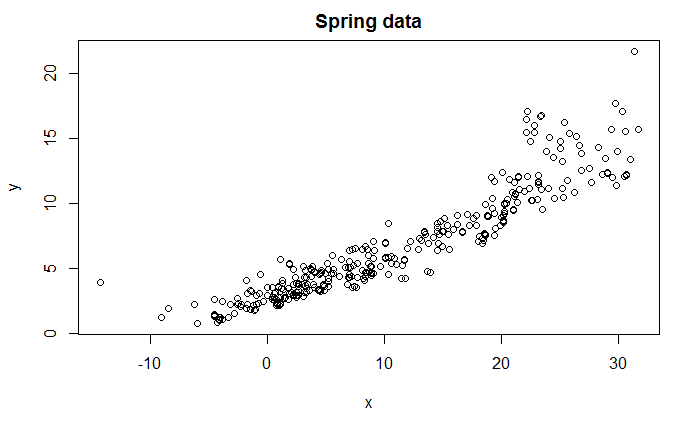

```r
  y <- data.sp$y
  x <- data.sp$x
  z <- data.sp$z
  e <- data.sp$e
  plot(x, y, main="Spring data")
```

```r
  mod <- lm(y ~ x + I(x^2) + z + e)
  sum_mod <- summary(mod)
  sum_mod
```

```
Call:
lm(formula = y ~ x + I(x^2) + z + e)

Residuals:
    Min      1Q  Median      3Q     Max
-2.6834 -0.6510 -0.1095  0.4420  5.7359

Coefficients:
              Estimate Std. Error t value Pr(>|t|)
(Intercept)  1.9788336  0.1909791  10.362  < 2e-16 ***
x            0.0019461  0.0238836   0.081 0.935106
I(x^2)       0.0070939  0.0006183  11.474  < 2e-16 ***
z            0.0427825  0.0032299  13.246  < 2e-16 ***
e           -0.0008679  0.0002387  -3.636 0.000318 ***
---
Signif. codes:  0 ‘***’ 0.001 ‘**’ 0.01 ‘*’ 0.05 ‘.’ 0.1 ‘ ’ 1

Residual standard error: 1.111 on 348 degrees of freedom
Multiple R-squared:  0.9248,    Adjusted R-squared:  0.924
F-statistic:  1070 on 4 and 348 DF,  p-value: < 2.2e-16
```

#### Model diagnostics

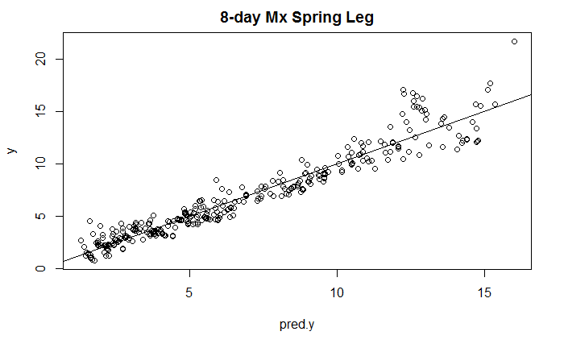

```r
  pred.y <- predict(mod)
  pred.y[pred.y < -0.5] = -0.5
  {plot(pred.y, y, main = paste0("8-day ", var, " Spring Leg"))
  abline(0,1)}
```

Test assumption of linear model

```r
  post_mod <- summary(lm(y ~ pred.y))
  gvmodel <- gvlma(mod)
  summary(gvmodel)
```

```
Call:
lm(formula = y ~ x + I(x^2) + z + e)

Residuals:
    Min      1Q  Median      3Q     Max
-2.6834 -0.6510 -0.1095  0.4420  5.7359

Coefficients:
              Estimate Std. Error t value Pr(>|t|)
(Intercept)  1.9788336  0.1909791  10.362  < 2e-16 ***
x            0.0019461  0.0238836   0.081 0.935106
I(x^2)       0.0070939  0.0006183  11.474  < 2e-16 ***
z            0.0427825  0.0032299  13.246  < 2e-16 ***
e           -0.0008679  0.0002387  -3.636 0.000318 ***
---
Signif. codes:  0 ‘***’ 0.001 ‘**’ 0.01 ‘*’ 0.05 ‘.’ 0.1 ‘ ’ 1

Residual standard error: 1.111 on 348 degrees of freedom
Multiple R-squared:  0.9248,    Adjusted R-squared:  0.924
F-statistic:  1070 on 4 and 348 DF,  p-value: < 2.2e-16


ASSESSMENT OF THE LINEAR MODEL ASSUMPTIONS
USING THE GLOBAL TEST ON 4 DEGREES-OF-FREEDOM:
Level of Significance =  0.05

Call:
 gvlma(x = mod)

                    Value  p-value                   Decision
Global Stat        559.06 0.00e+00 Assumptions NOT satisfied!
Skewness           104.75 0.00e+00 Assumptions NOT satisfied!
Kurtosis           269.79 0.00e+00 Assumptions NOT satisfied!
Link Function       53.78 2.24e-13 Assumptions NOT satisfied!
Heteroscedasticity 130.73 0.00e+00 Assumptions NOT satisfied!
```

check for outliers

```r
  outlierTest(mod)
```

```
    rstudent unadjusted p-value Bonferonni p
353 5.479483         8.2139e-08   2.8995e-05
352 4.502347         9.1896e-06   3.2439e-03
338 4.140723         4.3517e-05   1.5362e-02
340 3.906287         1.1266e-04   3.9770e-02
```

plot model diagnostics

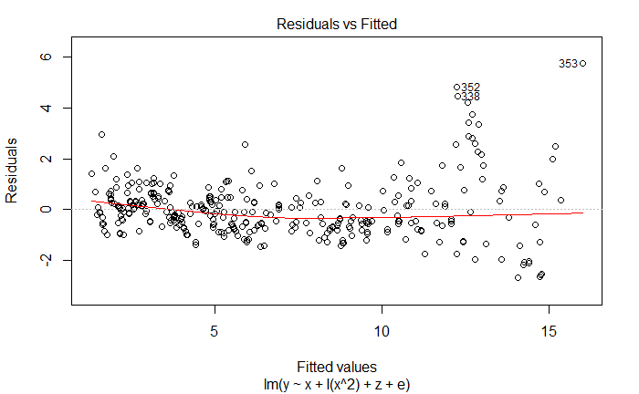

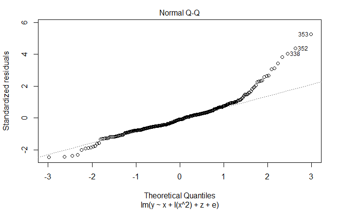

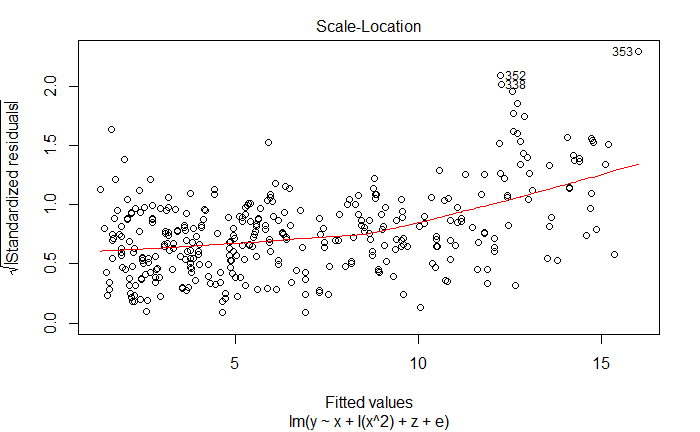

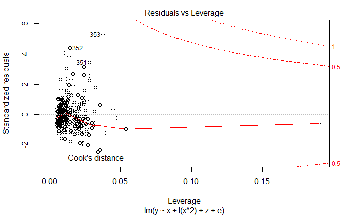

```r
  plot(mod)
```

rerun w/o outliers

```r
  mod <- lm(y ~ x + I(x^2) + z + e, data=data.sp[-c(324,337,338,340,351,352,353), ])
```

recheck for outliers

```r
  outlierTest(mod)
```

```
No Studentized residuals with Bonferonni p < 0.05
Largest |rstudent|:
    rstudent unadjusted p-value Bonferonni p
336 3.745924         0.00021106     0.073026
```

recheck assumptions

```r
  gvmodel <- gvlma(mod)
  summary(gvmodel)
```

```
Call:
lm(formula = y ~ x + I(x^2) + z + e, data = data.sp[-c(324, 337,
    338, 340, 351, 352, 353), ])

Residuals:
    Min      1Q  Median      3Q     Max
-2.3130 -0.5855 -0.1051  0.4294  3.3163

Coefficients:
              Estimate Std. Error t value Pr(>|t|)
(Intercept)  2.0991805  0.1581851  13.270  < 2e-16 ***
x            0.0342665  0.0198160   1.729 0.084673 .
I(x^2)       0.0062378  0.0005159  12.090  < 2e-16 ***
z            0.0375286  0.0026966  13.917  < 2e-16 ***
e           -0.0007458  0.0001993  -3.742 0.000214 ***
---
Signif. codes:  0 ‘***’ 0.001 ‘**’ 0.01 ‘*’ 0.05 ‘.’ 0.1 ‘ ’ 1

Residual standard error: 0.914 on 341 degrees of freedom
Multiple R-squared:  0.9416,    Adjusted R-squared:  0.9409
F-statistic:  1374 on 4 and 341 DF,  p-value: < 2.2e-16


ASSESSMENT OF THE LINEAR MODEL ASSUMPTIONS
USING THE GLOBAL TEST ON 4 DEGREES-OF-FREEDOM:
Level of Significance =  0.05

Call:
 gvlma(x = mod)

                    Value   p-value                   Decision
Global Stat        176.46 0.000e+00 Assumptions NOT satisfied!
Skewness            40.46 2.004e-10 Assumptions NOT satisfied!
Kurtosis            38.98 4.289e-10 Assumptions NOT satisfied!
Link Function       27.14 1.893e-07 Assumptions NOT satisfied!
Heteroscedasticity  69.88 1.110e-16 Assumptions NOT satisfied!
```

more tests: qqplot

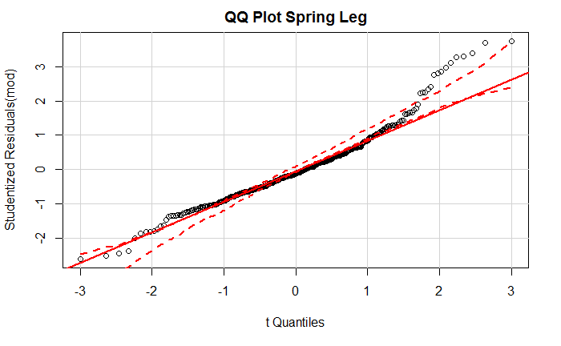

```r
  qqPlot(mod, main="QQ Plot Spring Leg")
```

if outliers need to be removed (otherwise skip)

```r
  data.sp <- data.sp[-c(324,337,338,340,351,352,353), ]
  y <- data.sp$y
  x <- data.sp$x
  z <- data.sp$z
  e <- data.sp$e
  mod <- lm(y ~ x + I(x^2) + z + e)
  sum_mod <- summary(mod)
```

format the data for prediction output

```r
  pressstat_sum <- PRESS(sum_mod, verbose = "FALSE")

  coeffs <- as.matrix(coefficients(mod))
  pred.y <- predict(mod)

  pred.y[pred.y < -0.5] = -0.5
```

Look at the residuals

```
Suggested power transformation:  0.4673948
```

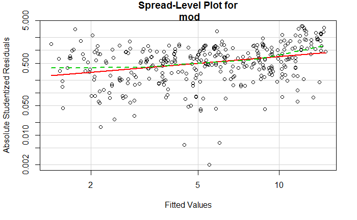

```r
  spreadLevelPlot(mod)
```

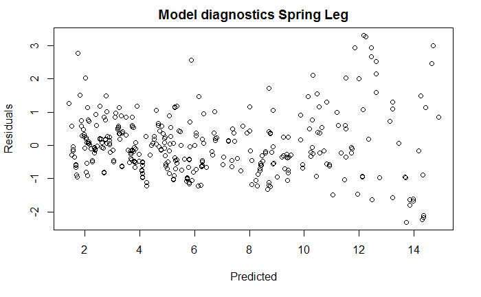

```r
  plot(pred.y, mod$residuals, main="Model diagnostics Spring Leg", xlab="Predicted", ylab="Residuals")
```

LOO PRESS stats

```r
  pressstat_sum <- PRESS(sum_mod, verbose = "FALSE")
  RMSEP <- sqrt(mean((pressstat_sum$residuals)^2))

  library(pls)
  mod2 <- plsr(y ~ x + I(x^2) + z +e, validation = "LOO")
  p2 <- R2(mod2)
  detach("package:pls", unload=TRUE)
```

write out predicted, coeffs, & metrics

```r
  pred.out <- matrix(nrow=length(pred.y), ncol=5)
  pred.out[,1] <- y
  pred.out[,2] <- pred.y
  pred.out[,3] <- z
  pred.out[,4] <- "Spring"
  pred.out[,5] <- yearPath
  colnames(pred.out) <- c("Y", "PredY", "JulDay", "Season", "Year")
  write.table (x=pred.out,append=F,row.names=F,file=paste0("jk_pred_v_y_", var, "_", basin, "_", yearPath, "_sp_fall.csv"),sep = ",", col.names=F)
```

```r
  coeffs_out[1,1] <- coeffs[1,1]
  coeffs_out[1,2] <- coeffs[2,1]
  coeffs_out[1,3] <- coeffs[3,1]
  coeffs_out[1,4] <- coeffs[4,1]
  coeffs_out[1,5] <- coeffs[5,1]

  metrics_out[1,1] <- sum_mod$adj.r.squared
  metrics_out[1,2] <- sum_mod$sigma
  metrics_out[1,3] <- p2$val[5]
  metrics_out[1,4] <- RMSEP
  metrics_out[1,5] <- length(unique(data.sp$SiteName))
  metrics_out[1,6] <- length(y)
```

Fall data model

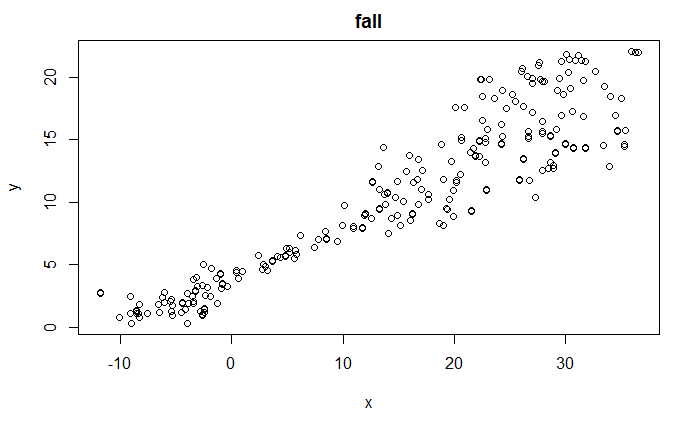

```r
  y <- data.fall$y
  x <- data.fall$x
  z <- data.fall$z
  e <- data.fall$e
  plot(x, y, main="fall")
```

```r
  mod <- lm(y ~ x + I(x^2) + z +e)
  sum_mod <- summary(mod)
  sum_mod
```

```
Call:
lm(formula = y ~ x + I(x^2) + z + e)

Residuals:
    Min      1Q  Median      3Q     Max
-3.9989 -1.1834 -0.1417  1.0113  4.9552

Coefficients:
              Estimate Std. Error t value Pr(>|t|)
(Intercept) 29.0046720  2.1118985  13.734  < 2e-16 ***
x            0.1816731  0.0308499   5.889 1.24e-08 ***
I(x^2)      -0.0009917  0.0007450  -1.331    0.184
z           -0.0676662  0.0063951 -10.581  < 2e-16 ***
e           -0.0043910  0.0006673  -6.581 2.71e-10 ***
---
Signif. codes:  0 ‘***’ 0.001 ‘**’ 0.01 ‘*’ 0.05 ‘.’ 0.1 ‘ ’ 1

Residual standard error: 1.816 on 251 degrees of freedom
Multiple R-squared:  0.9189,    Adjusted R-squared:  0.9176
F-statistic: 710.9 on 4 and 251 DF,  p-value: < 2.2e-16
```